# Data Summarization in Python

In this notebook we are going to attempt to reproduce [this](http://mlbernauer.com/pages/cms/) blog post using data from the [Centers for Medicare and Medicaid Services (CMS)](https://www.cms.gov/) and Python.

We will first start by downloading the Public Use File which is available from here[http://download.cms.gov/Research-Statistics-Data-and-Systems/Statistics-Trends-and-Reports/Medicare-Provider-Charge-Data/Downloads/PartD_Prescriber_PUF_NPI_DRUG_13.zip] the file is quite large (489MB) so make sure you have enough space on your machine. We will then use Pandas which is python library useful for manipulating data. Pandas is similar to [R](https://cran.r-project.org/) in the sense that has a similar data frame object that is used for storing tables and conducting a variety of data munging tasks such as transformations and computing aggregate statistics using the 'Split-Apply-Combine' method. Finally, we will use a variety of different plotting libraries to visualize our results.

## Objectives:

1. Compute top drugs by total number of claims
2. Compute top most costly drugs
3. Compute top drugs by total beneficiary count

```python
# import libraries
import pandas as pd
```

## Loading the data

Because the file is large (~23 million rows x 19 columns) we will only select a few key columns to reduce the amount of RAM required to hold the dataframe. The data comes aggregated by NPI and Drug, thus each NPI may appear multiple times, once for each drug that provide has written a prescription for.

```python
columns = ['NPI',
           'NPPES_PROVIDER_STATE',
           'DRUG_NAME',
           'GENERIC_NAME',
           'SPECIALTY_DESC',
           'TOTAL_CLAIM_COUNT',
           'TOTAL_DRUG_COST',
           'BENE_COUNT']

# load the data for select columns using the 'c' engine for speed
df = pd.read_csv("PARTD_PRESCRIBER_PUF_NPI_DRUG_13.tab", sep='\t', usecols=columns, engine='c')
```

Lets get some info on our dataframe (i.e. size, datatypes)

```python
df.info()
```

```
<class 'pandas.core.frame.DataFrame'>
Int64Index: 23650520 entries, 0 to 23650519
Data columns (total 8 columns):
NPI                     int64
NPPES_PROVIDER_STATE    object
SPECIALTY_DESC          object
DRUG_NAME               object
GENERIC_NAME            object
BENE_COUNT              float64
TOTAL_CLAIM_COUNT       int64
TOTAL_DRUG_COST         float64
dtypes: float64(2), int64(2), object(4)
memory usage: 1.6+ GB
```

We see there are 23,650,520 rows and 8 columns of data which take up about 1.6GB of RAM. We also see that the data types are a mix if integers, floats and 'objects'.

## Top drugs by total number of claims

Alright, lets first start by computing the most popular drugs according to the total number of claims for that drug. For this example we will use the generic name of the drug

```python
method = {'TOTAL_CLAIM_COUNT':'sum'}
top_claims = df.groupby('GENERIC_NAME',
                        as_index=False).agg(method).sort_values(by='TOTAL_CLAIM_COUNT',
                                                                ascending=False).head(50)
```

```python
top_claims.head(10)
```

|  | GENERIC_NAME | TOTAL_CLAIM_COUNT |
| --- | --- | --- |
| 819 | LEVOTHYROXINE SODIUM | 40040908 |
| 837 | LISINOPRIL | 36213182 |
| 1347 | SIMVASTATIN | 36185092 |
| 78 | AMLODIPINE BESYLATE | 33951483 |
| 678 | HYDROCODONE/ACETAMINOPHEN | 33521291 |
| 1068 | OMEPRAZOLE | 31500544 |
| 112 | ATORVASTATIN CALCIUM | 26205342 |
| 620 | FUROSEMIDE | 25707232 |
| 887 | METFORMIN HCL | 25065694 |
| 924 | METOPROLOL TARTRATE | 20368244 |

We see that the top drugs based on total number of claims include statins, $\beta$-blockers, calcium-channel blockers, proton pump inhibitors, diuretics, anit-hyperglycemics and pain relievers, all of which you would expect given the burden these diseases on the US population

## Top drugs by total spend

Now lets compute the most costly drugs by total spend. For this we'll be grouping on both `DRUG_NAME` which includes the brand name if brand name was prescribed.

```python
method = {'TOTAL_DRUG_COST':'sum'}
top_brands = df.groupby(['DRUG_NAME',
                         'GENERIC_NAME'],
                        as_index=False).agg(method).sort_values(by='TOTAL_DRUG_COST',
                                                                ascending=False).head(50)
```

```python
top_brands.head(10)
```

|  | DRUG_NAME | GENERIC_NAME | TOTAL_DRUG_COST |
| --- | --- | --- | --- |
| 1752 | NEXIUM | ESOMEPRAZOLE MAGNESIUM | 2.320291e+09 |
| 615 | CRESTOR | ROSUVASTATIN CALCIUM | 2.089238e+09 |
| 50 | ADVAIR DISKUS | FLUTICASONE/SALMETEROL | 2.069282e+09 |
| 4 | ABILIFY | ARIPIPRAZOLE | 1.878588e+09 |
| 2335 | SPIRIVA | TIOTROPIUM BROMIDE | 1.778776e+09 |
| 636 | CYMBALTA | DULOXETINE HCL | 1.777237e+09 |
| 1707 | NAMENDA | MEMANTINE HCL | 1.452010e+09 |
| 1314 | JANUVIA | SITAGLIPTIN PHOSPHATE | 1.308959e+09 |
| 1385 | LANTUS SOLOSTAR | INSULIN GLARGINE,HUM.REC.ANLOG | 1.210243e+09 |
| 2200 | REVLIMID | LENALIDOMIDE | 1.182224e+09 |

We see that the top drugs by total spend again include proton-pump inhibitors, statins, bronchodilators, antihyperglycemic drugs and even some antipsychotics and antidepressants. From this table alone, it is impossible to tell whether or not this is due to the price of the medications or because they are prescribed much more frequently than other medications.

## Top drugs by total beneficiary count

A beneficiary is someone who's enrolled in Medicare Part D and who is recieving these medications as a result of their prescription benefits. Lets rank the drugs by total beneficiary count

```python
method = {'BENE_COUNT':'sum'}
top_bene = df.groupby(['GENERIC_NAME'],
                     as_index=False).agg(method).sort_values(by='BENE_COUNT',
                                                            ascending=False).head(50)
```

```python
top_bene.head(10)
```

|  | GENERIC_NAME | BENE_COUNT |
| --- | --- | --- |
| 678 | HYDROCODONE/ACETAMINOPHEN | 10844363 |
| 837 | LISINOPRIL | 8096692 |
| 1347 | SIMVASTATIN | 7810499 |
| 819 | LEVOTHYROXINE SODIUM | 7408339 |
| 78 | AMLODIPINE BESYLATE | 7048423 |
| 1068 | OMEPRAZOLE | 6902028 |
| 112 | ATORVASTATIN CALCIUM | 5689020 |
| 620 | FUROSEMIDE | 5609265 |
| 887 | METFORMIN HCL | 4953388 |
| 125 | AZITHROMYCIN | 4835918 |

# Visualizing the results:

## ggplot

Since we are simply aggregating stats for categorical variables, an appropriate way to visualize these valuels would be to plot them using a bar-plot. In the next few sections we will plot the aggregate stats we computed earlier to provide a visual aid to better understand them. For this section we will be using a library called `ggplot` which is also implemented in R. ggplot draws extensively from 'grammar of graphics' which establishes principles for building visually compelling figures.

## Top drugs by total number of claims

ggplot allows figures to be built incrementally by adding on layers. The first function `ggplot()` establishes mappings from the data to `aesthetic` parameters. `geom_bar()` tells ggplot we wan to use a barplot, `theme_bw()` adds the *black and white* theme to our figure while `theme()` exposes some of the formatting paramters. Finally, we add labels to our figure using the `labs()` function.

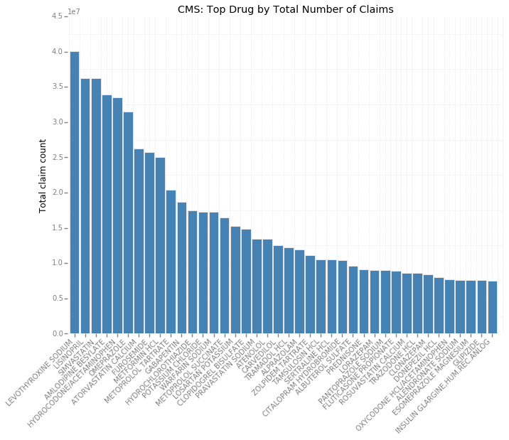

```python
from ggplot import *
# plot figures in Jupyter notebook
%matplotlib inline

p = ggplot(aes(x='factor(GENERIC_NAME)', y='TOTAL_CLAIM_COUNT'), data=top_claims.head(40)) + \
    geom_bar(stat='identity', fill='steelblue') + \
    theme_bw()+ theme(axis_text_x = element_text(angle=45, hjust=1)) + \
    labs(title="CMS: Top Drug by Total Number of Claims", x=" ", y="Total claim count")
p
```

## Top drugs by total spend

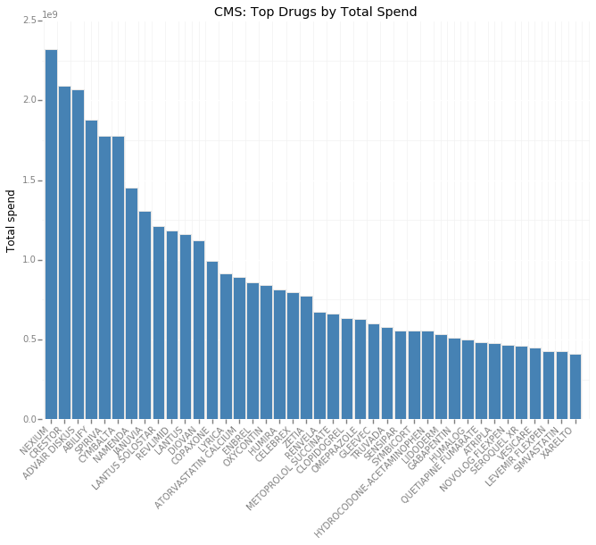

```python
p = ggplot(aes(x='DRUG_NAME', y='TOTAL_DRUG_COST'), data=top_brands.head(40)) + \
    geom_bar(stat='identity', fill='steelblue') + \
    theme_bw() + theme(axis_text_x = element_text(angle=45, hjust=1)) + \
    labs(title="CMS: Top Drugs by Total Spend", x=" ", y="Total spend")
p
```

## Top drugs by total beneficiary count

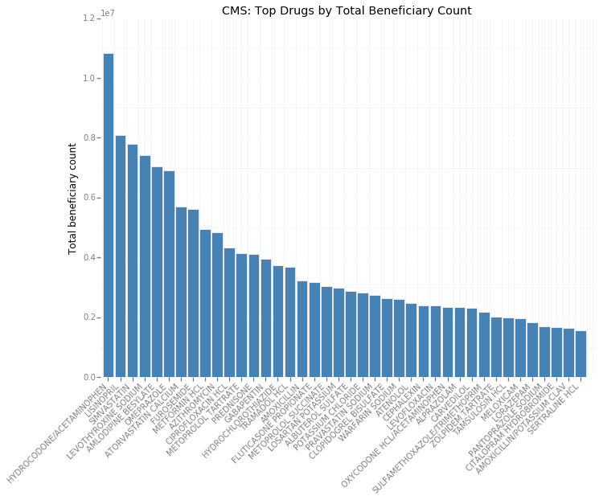

```python
p = ggplot(aes(x='GENERIC_NAME', y='BENE_COUNT'), data=top_bene.head(40)) + \
    geom_bar(stat='identity', fill='steelblue') + \
    theme_bw() + theme(axis_text_x = element_text(angle=45, hjust=1)) + \
    labs(title="CMS: Top Drugs by Total Beneficiary Count", x=" ", y="Total beneficiary count")
p
```

## Top drugs by total number of claims

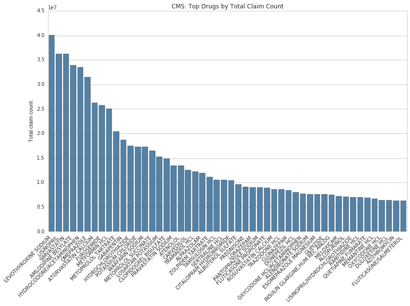

```python
import seaborn as sns
import matplotlib.pyplot as plt
sns.set_style('whitegrid')
plt.figure(figsize=(13,8))
bp = sns.barplot(x="GENERIC_NAME", y="TOTAL_CLAIM_COUNT", data=top_claims, color="steelblue")
plt.title("CMS: Top Drugs by Total Claim Count")
plt.xlabel("")
plt.ylabel("Total claim count")
ax = bp.set_xticklabels(top_claims.GENERIC_NAME, rotation=45, ha='right', size=10)
```

## Top drugs by total spend

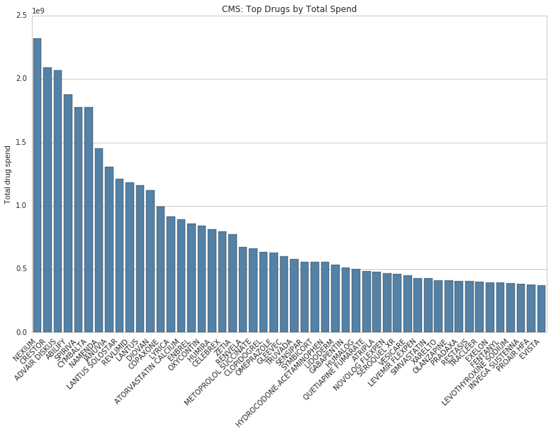

```python
sns.set_style('whitegrid')
plt.figure(figsize=(13,8))
bp = sns.barplot(x="DRUG_NAME", y="TOTAL_DRUG_COST", data=top_brands, color="steelblue")
plt.title("CMS: Top Drugs by Total Spend")
plt.xlabel("")
plt.ylabel("Total drug spend")
ax = bp.set_xticklabels(top_brands.DRUG_NAME, rotation=45, ha='right', size=10)
```

## Top drugs by total beneficiary count

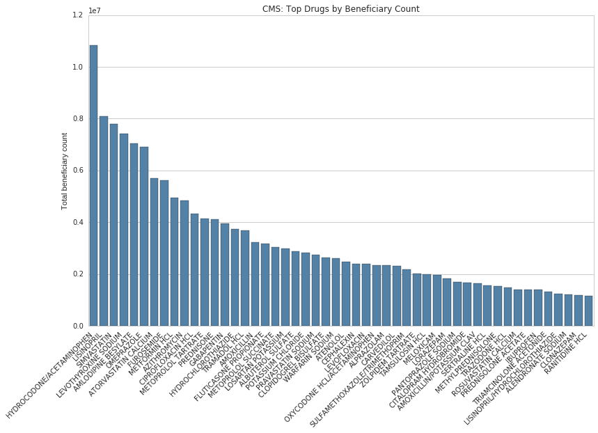

```python
sns.set_style('whitegrid')
plt.figure(figsize=(13,8))
bp = sns.barplot(x="GENERIC_NAME", y="BENE_COUNT", data=top_bene, color="steelblue")
plt.title("CMS: Top Drugs by Beneficiary Count")
plt.xlabel("")
plt.ylabel("Total beneficiary count")
ax = bp.set_xticklabels(top_bene.GENERIC_NAME, rotation=45, ha='right', size=10)
```

## Matplotlib

### Top drugs by total number of claims

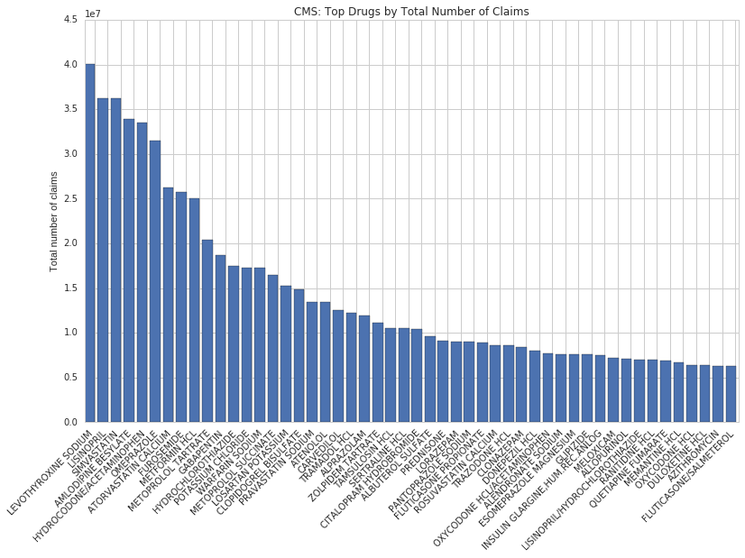

```python
import numpy as np
plt.style.use('seaborn-notebook')
col = plt.rcParams['axes.color_cycle'][0]
fig, ax = plt.subplots(1, 1, figsize=(13, 8))
n = np.arange(0, top_claims.shape[0], 1)
plt.bar(n, top_claims.TOTAL_CLAIM_COUNT, color=col)
ax.set_xticks(n+0.75)
ax.set_xticklabels(top_claims.GENERIC_NAME, rotation=45, ha='right')
plt.title('CMS: Top Drugs by Total Number of Claims')
plt.xlabel('')
plt.ylabel('Total number of claims')
plt.show()
```

### Top drugs by total spend

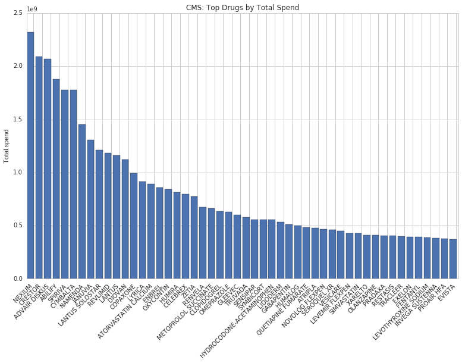

```python
fig, ax = plt.subplots(1, 1, figsize=(13, 8))
n = np.arange(0, top_brands.shape[0], 1)
plt.bar(n, top_brands.TOTAL_DRUG_COST, color=col)
ax.set_xticks(n+0.75)
ax.set_xticklabels(top_brands.DRUG_NAME, rotation=45, ha='right')
plt.title('CMS: Top Drugs by Total Spend')
plt.xlabel('')
plt.ylabel('Total spend')
plt.show()
```

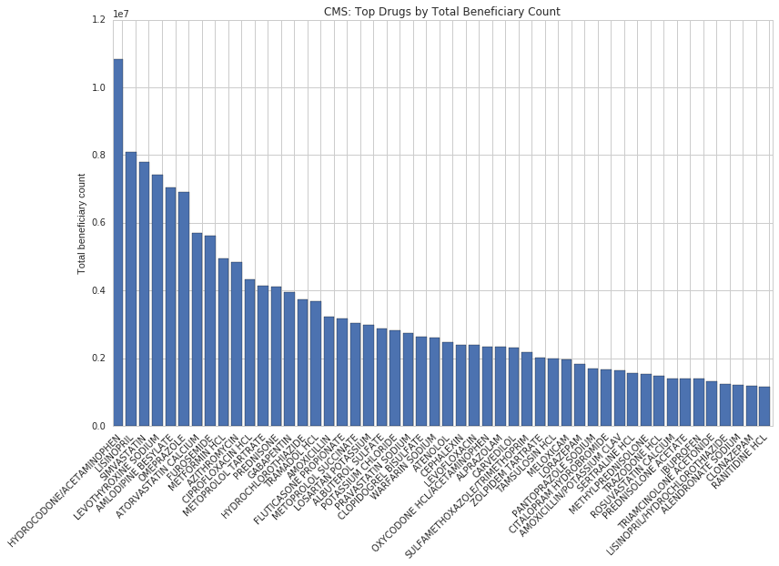

```python
fig, ax = plt.subplots(1,1,figsize=(13,8))
n = np.arange(0, top_bene.shape[0], 1)
plt.bar(n, top_bene.BENE_COUNT, color=col)
ax.set_xticks(n + 0.75)
ax.set_xticklabels(top_bene.GENERIC_NAME, rotation=45, ha='right')
plt.title('CMS: Top Drugs by Total Beneficiary Count')
plt.xlabel('')
plt.ylabel('Total beneficiary count')
plt.show()
```

# Scatter Plots

In this next section we will use scatterplots to visualize the relationships between some of the aggregate stats grouped by drug.

```python
# total claims vs total cost
aggfnc = {'TOTAL_CLAIM_COUNT':'sum', 'TOTAL_DRUG_COST':'sum', 'BENE_COUNT':'sum'}
claims_cost = df.groupby('GENERIC_NAME', as_index=False).agg(aggfnc)
```

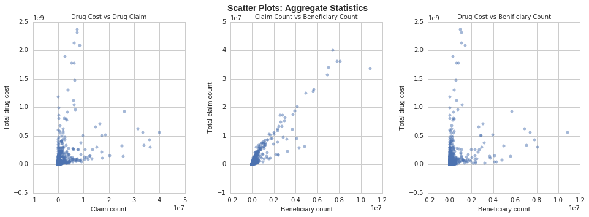

```python
#plt.style.use('seaborn-notebook')
#col = plt.rcParams['axes.color_cycle'][0]
plt.figure(figsize=(16,5))
plt.subplots_adjust(wspace=0.3)
plt.suptitle('Scatter Plots: Aggregate Statistics', fontsize=14, fontweight='bold')

plt.subplot(131)
plt.scatter(claims_cost.TOTAL_CLAIM_COUNT, claims_cost.TOTAL_DRUG_COST, color = col, alpha=0.5)
plt.title('Drug Cost vs Drug Claim', size=10)
plt.ylabel('Total drug cost')
plt.ylim()
plt.xlim()
plt.grid(True)
plt.xlabel('Claim count')

plt.subplot(132)
plt.scatter(claims_cost.BENE_COUNT, claims_cost.TOTAL_CLAIM_COUNT, color = col, alpha=0.5)
plt.title('Claim Count vs Beneficiary Count', size=10)
plt.ylabel('Total claim count')
plt.grid(True)
plt.xlabel('Beneficiary count')

plt.subplot(133)
plt.scatter(claims_cost.BENE_COUNT, claims_cost.TOTAL_DRUG_COST, color=col, alpha=0.5)
plt.title('Drug Cost vs Benificiary Count', size=10)
plt.xlabel('Beneficiary count')
plt.ylabel('Total drug cost')
plt.show()
```

# Conclusion